# Reproducing results in ‘Geometric ergodicity of trans-dimensional Markov chain Monte Carlo algorithms’

# Section 4.3

In this section, we generate Figure 3 in Section 4.3 of the manuscript.

The code for simulating the Markov chain for the Bayesian Gaussian mixture model can be found in “functions_4_3.R”.

```r
source("functions_4_3.R", local = knitr::knit_global())
```

The data set analyzed is the “galaxies” data set in the “MASS” package. Note that one of the numbers in the data set is incorrect; see Roeder’s 1990 paper “Density estimation with confidence sets exemplified by superclusters and voids in the galaxies.”

```r
galaxy <- galaxies/1000
galaxy[78] <- 26.96
```

The following code chunk can be used to simulate the chain.

```r
# Initialization and hyperparameter specification:
set.seed(12)
mykmax <- 30
mypk <- 1/2^seq(1:mykmax)
mymu0 <- 20
mytau0 <- 1000
mya0 <- 3
myb0 <- 2
myalpha0 <- 2
mykini <- rbinom(1,mykmax, 0.5)
mylength <- 1e5
```

```r
# chain simulation:
mymixchain <- mixRJMCMC(mylength, galaxy, mymu0, tau0=mytau0, mya0, b0=myb0, alpha0=myalpha0, mypk,
                        mykini, sample(seq(1,mykini),length(galaxy),replace=T), rep(1/mykini,mykini), rep(1,mykini), rep(0,mykini),
                        jumppar=1/3)
```

We do run the above code chunk to save time. Instead, we load a copy of the simulated chain.

```r
load(file="../output/chain.mix.RData")
```

We can use the simulation output to predict the density function of the data set.

```r
# calculate predicted density
y.axis <- seq(5, 40, 0.2)
density.pred <- rep(0, length(y.axis))
for (t in 1:mylength) {
  for (j in 1:length(y.axis)) {
    density.pred[j] <- density.pred[j] + sum(mymixchain$w[t,]*
                                               dnorm(y.axis[j], mymixchain$mu[t,], sqrt(mymixchain$tau[t,])+1e-20) )
  }
}

density.pred <- density.pred/mylength


df.mixture.1 <- data.frame(x=galaxy)
df.mixture.2 <- data.frame(x=y.axis, density=density.pred)
```

Now we can reproduce the four plots in Figure 3.

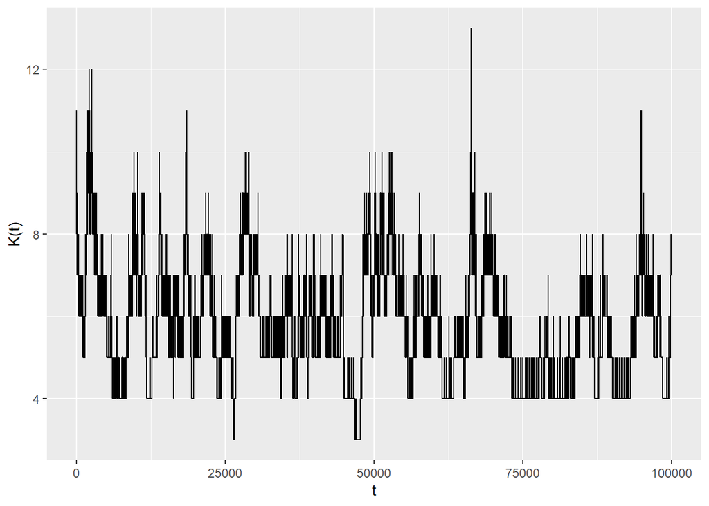

```r
df.mixture.chain <- data.frame(t=1:mylength, k=mymixchain$k[1:mylength])
# the chain when K(t)=5:
df.mixture.chain.5 <- data.frame(t=1:length(which(mymixchain$k==5)),
                                 u=mymixchain$mu[which(mymixchain$k==5),2])

# first plot: trace plot of K(t)
p.mix.trace.k <- ggplot(df.mixture.chain, aes(x=t, y=k)) + geom_line() + labs(y="K(t)") +
  scale_y_continuous(breaks=c(4,8,12))
p.mix.trace.k
```

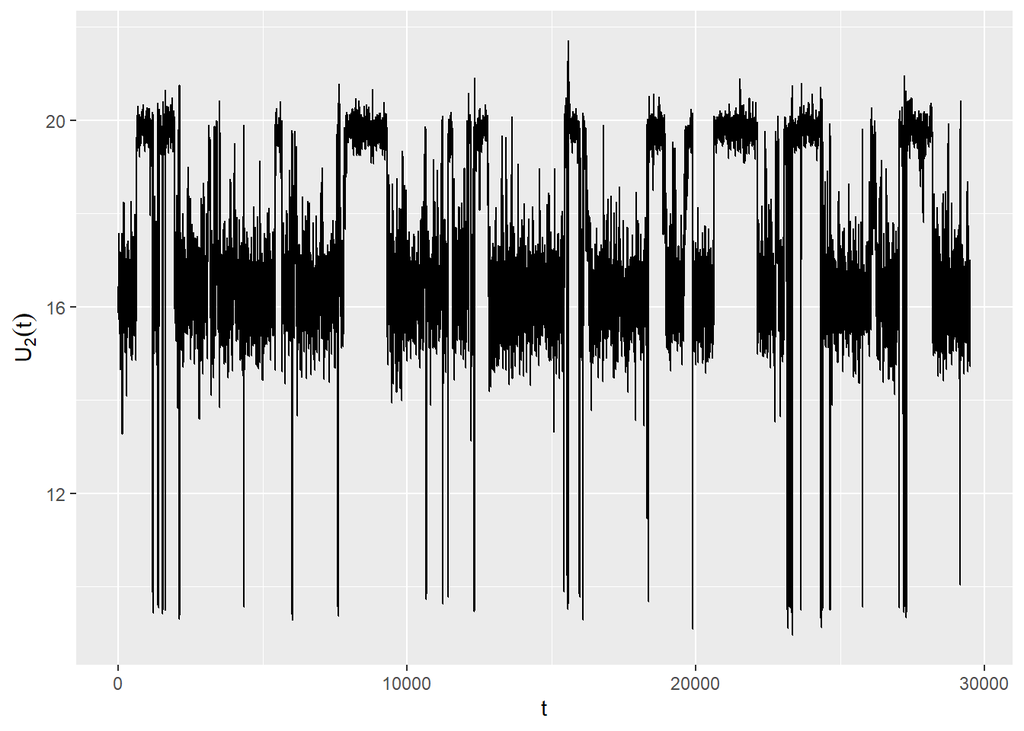

```r
# second plot: trace plot of U2(t) when K(t) = 5.
p.mix.trace.u <- ggplot(df.mixture.chain.5, aes(x=t, y=u)) + geom_line() + labs(y=expression(U[2](t)))
p.mix.trace.u
```

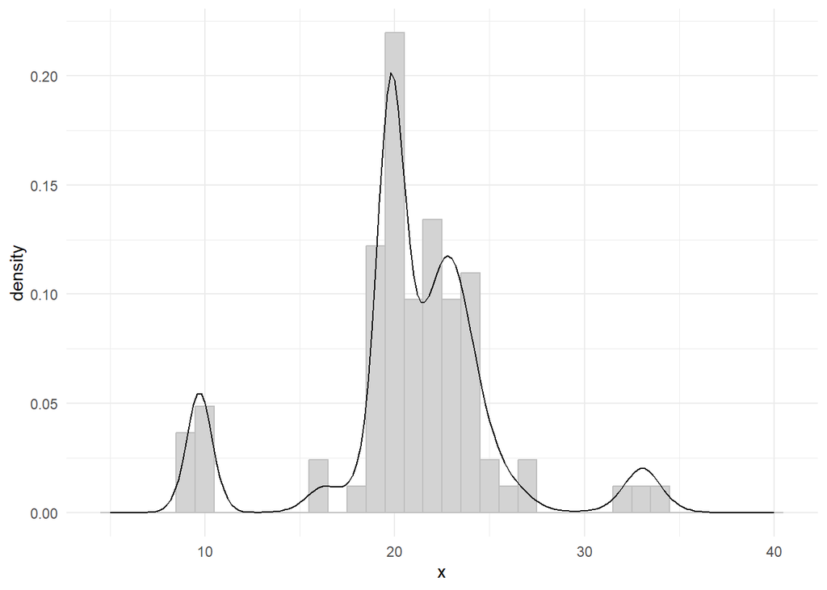

```r
# third plot: predicted density with histogram
p.mix.density <- ggplot(df.mixture.1, aes(x = x, y=after_stat(density))) +
  geom_histogram(colour = "grey", fill = "lightgrey", binwidth=1) + theme_minimal() +
  geom_line(data=df.mixture.2, aes(x,density))
p.mix.density
```

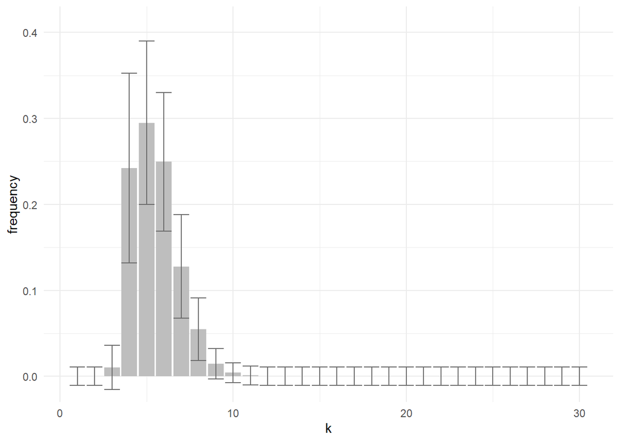

```r
# fourth plot: get confidence intervals for the posterior probabilities of K
chain.mixture.length <- length(mymixchain$k)
mixture.kind <- matrix(rep(0,chain.mixture.length*30), ncol=30)
for (i in 1:chain.mixture.length) {
  mixture.kind[i,mymixchain$k[i]] <- 1
}
kvar.mixture<- batchmeans(mixture.kind)
kmean.mixture <- apply(X=mixture.kind, MARGIN=2, FUN=mean)
intervals.mixture <- get.intervals(0.05, kmean.mixture, kvar.mixture, chain.mixture.length, adjusted=T)
df.mixture.k <- as.data.frame(intervals.mixture)
df.mixture.k$k <- seq(1,30)
names(df.mixture.k) <- c( "left", "frequency", "right", "k")

p.mix.k <- ggplot(data = df.mixture.k, aes(x = k, y = frequency)) +
  geom_bar(stat="identity", fill = "grey") +
  geom_errorbar(aes(x = k, ymin=left, ymax=right ), color="dimgrey") +
  scale_y_continuous(expand = c(0, 0), limits = c(-0.03, 0.43)) +
  theme_minimal()
p.mix.k
```

# Supplement I-E

This section contains the code for reproducin Table A in Section E of Supplement I. In this section, we compute the empirical coverage probability for a toy MCMC algorithm.

Some functions from “functions_supp_I_E.R” are needed. The file contains a function that simulates the toy chain, and a function `get.coverage.rate` that calculates the empirical coverage rates through repeated simulations.

```r
source("functions_supp_I_E.R", local = knitr::knit_global())
```

The following code chunk reproduces Table A in the supplement.

```r
set.seed(11)
coverage.rate.1 <- get.coverage.rate(5e3,trialrep=1000,c(0.1,0.05),10,15)
coverage.rate.2 <- get.coverage.rate(5e4,trialrep=1000,c(0.1,0.05),10,15)
```

To save time, we will instead load the result from the file “coverage.rates.RData”.

```r
load("../output/coverage.rates.RData")
```

The empirical probabilities in Table A can be found in the following table.

```r
coverage.rate.1
```

```
##      truth nominal inflate empirial     length
## [1,]   0.1    0.90       0    0.796 0.03796626
## [2,]   0.1    0.90       1    0.997 0.05929019
## [3,]   0.1    0.95       0    0.842 0.04137409
## [4,]   0.1    0.95       1    0.999 0.06461203
```

```r
coverage.rate.2
```

```
##      truth nominal inflate empirial     length
## [1,]   0.1    0.90       0    0.888 0.01257344
## [2,]   0.1    0.90       1    0.996 0.01798701
## [3,]   0.1    0.95       0    0.935 0.01370202
## [4,]   0.1    0.95       1    0.999 0.01960151
```

# Supplement II

This section reproduces Figure a in Supplement II. A reversible jump algorithm for Bayesian robust autoregression is be simulated, and confidence intervals will be constructed for the posterior probability of each model order.

Functions for simulating the chain are given in the file “functions_supp_II.R”.

```r
source("functions_supp_II.R", local = knitr::knit_global())
```

We use a simulated data set to form the posterior. The hyperparameters and initialization for the chain are also given.

```r
# simulated data
set.seed(11)
myn <- 100
myp <- 50
k.true <- 4
kappa <- 10 # max of k
b.true <- rnorm(myp, 0, 1)
# a.true <- c(0.3,0.05,0.05,0.05)
a.true <- c(0.3,0.25,0.05,0.05)
tau.true <- 1
myX <- matrix(rnorm(myn*myp, 0, 1), ncol=myp)
myy.start <- rnorm(kappa, 0, 1)
myy <- rep(0, myn)
myy.full <- c(myy.start, myy)

for (i in 1:myn) {
  myy.full[i+kappa] <- sum(myX[i,] * b.true)
  for (k in 1:k.true) {
    myy.full[i+kappa] <- myy.full[i+kappa] + a.true[k]*myy.full[i+kappa-k]
  }
  myy.full[i+kappa] <- myy.full[i+kappa] + sqrt((1/rgamma(1,1,1/8)))*rnorm(1,0,sqrt(tau.true))
}

myy <- myy.full[(kappa+1):(myn+kappa)]

# Prior specification
myprior.scale = 5
lambda <- 1
myprior.k <- dpois(0:kappa, lambda)/ppois(kappa, lambda)

# Markov chain initialization
set.seed(11)
k.ini <- 10
if (k.ini == 0) {a.ini <- 0} else {
  a.ini <- rnorm(k.ini, 0, 1)
}
b.ini <- rnorm(myp,0,1)
tau.ini <- rexp(1,1)
```

The following code chunk simulates the chain. We only need the component $K(t)$.

```r
# Markov chain simulation
set.seed(12)
chainlen <- 4e5
chain1 <- robust.mcmc(chainlen, k.ini, a.ini, b.ini, tau.ini,
                      myX, myy, myy.start, myprior.k, prior.a = 1, myprior.scale,
                      jumppar = 1/3)
chain1.k <- chain1$k
```

To save time, the $K(t)$ component of a copy of the simulated chain is loaded.

```r
load("../output/chain.robust.RData")
```

We then calculate the confidence intervals for the model order $k$ based on the simulation output. Note that we use the functions in `functions_uncertainty.R`.

```r
chainlen <- length(chain1.k)-1
chain1quantities <- matrix(rep(0, 11*(chainlen+1)), ncol = 11)
for (j in 1:11) {
  chain1quantities[,j] <- as.numeric(chain1.k == j-1)
}
chain1means <- apply(chain1quantities, 2, mean)
chain1var <- batchmeans(chain1quantities)
chain1intervals <- get.intervals(0.05, chain1means, chain1var, chainlen, adjusted=T)
df.robust <- as.data.frame(chain1intervals)
names(df.robust) <- c("left", "frequency", "right")
df.robust$k <- as.character(seq(0,10))
df.robust$k <- factor(df.robust$k, levels=df.robust$k)
```

The following code reproduces Figure a in Supplement II.

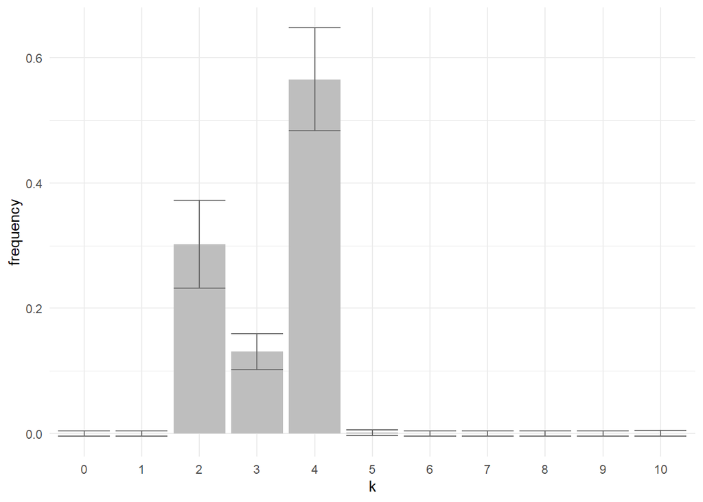

```r
hist.robust <- ggplot(data = df.robust, aes(x = k, y = frequency)) +
  geom_bar(stat="identity", fill = "grey") +
  geom_errorbar(aes(x = k, ymin=left, ymax=right ), color="dimgrey") +
  theme_minimal()
hist.robust
```